# R commands

Wame Mmolawa

2023-05-18

$\textbf{Data Analysis}$

```r
#load packages
load.lib <- c("readxl","sandwich","forecast","tseries","vars","urca","lmtest","tsDyn", "nortest","car","moments","tidyr","dplyr","aod","ggplot2","kableExtra","xts","quantmod","nnet","lawstat","TSA","strucchange","psych","ismev","gplots","timeSeries","Rcpp","plm","xtable","reshape2", "tinytex")
install.lib <- load.lib[!load.lib %in% installed.packages()]
for(lib in install.lib) install.packages(lib,dependencies=TRUE)
sapply(load.lib,require,character=TRUE)
```

```r
# Load the data
mydata <- read_excel(file.choose(), sheet = "Data")
head(mydata)
```

```
## # A tibble: 6 × 14
##   country  series.name `2010` `2011` `2012`  `2013` `2014` `2015`  `2016` `2017`
##   <chr>    <chr>        <dbl>  <dbl>  <dbl>   <dbl>  <dbl>  <dbl>   <dbl>  <dbl>
## 1 Botswana GDP         6.04e3 7.08e3 6.39e3 6.44e+3 6.84e3 5.87e3 6.41e+3 6.71e3
## 2 Botswana GOVEXP      3.08e1 2.83e1 3.18e1 3.11e+1 2.93e1 3.16e1 2.85e+1 2.89e1
## 3 Botswana TOP         9.46e1 9.90e1 1.12e2 1.26e+2 1.19e2 1.13e2 1.00e+2 8.19e1
## 4 Botswana FDI         1.73e0 1.94e0 1.05e0 4.70e-1 3.33e0 2.80e0 9.45e-1 1.62e0
## 5 Botswana INVEST      4.39e9 5.91e9 5.01e9 3.55e+9 3.91e9 3.85e9 3.33e+9 4.03e9
## 6 Botswana EXCHRATE    6.79e0 6.84e0 7.64e0 8.40e+0 8.98e0 1.01e1 1.09e+1 1.03e1
## # … with 4 more variables: `2018` <dbl>, `2019` <dbl>, `2020` <dbl>,
## #   `2021` <dbl>
```

```r
# Reshape the data
sacu <- pivot_longer(data = mydata,
cols=3:14,
names_to = "year",
values_to = "value")

sacu<- sacu %>%
pivot_wider(names_from = series.name, values_from = value)
head(sacu)
```

```
## # A tibble: 6 × 9
##   country  year    GDP GOVEXP   TOP   FDI      INVEST EXCHRATE INFLA
##   <chr>    <chr> <dbl>  <dbl> <dbl> <dbl>       <dbl>    <dbl> <dbl>
## 1 Botswana 2010  6042.   30.8  94.6 1.73  4385416554.     6.79  6.95
## 2 Botswana 2011  7081.   28.3  99.0 1.94  5911027478.     6.84  8.46
## 3 Botswana 2012  6393.   31.8 112.  1.05  5006684379.     7.64  7.54
## 4 Botswana 2013  6437.   31.1 126.  0.470 3550716225.     8.40  5.88
## 5 Botswana 2014  6844.   29.3 119.  3.33  3906663729.     8.98  4.40
## 6 Botswana 2015  5870.   31.6 113.  2.80  3848586988.    10.1   3.06
```

```r
# Transform variables to log scale
sacu$lnGDP <- log(abs(sacu$GDP))
sacu$lnGOVEXP <- log(abs(sacu$GOVEXP))
sacu$lnTOP <- log(abs(sacu$TOP))
sacu$lnFDI<- log(abs(sacu$FDI))
sacu$lnINVEST <- log(abs(sacu$INVEST))
sacu$lnEXCHRATE <- log(abs(sacu$EXCHRATE))
sacu$lnINFLA <- log(abs(sacu$INFLA))
```

```r
# Convert the sacu frame to a panel sacu object

psacu <- pdata.frame(sacu, index=c("country", "year"))[,-(3:9)]

# Create Lockdown dummy variable
psacu$LOCK <- ifelse(psacu$year == 2020, 1, 0)

head(psacu)
```

```
##                country year    lnGDP lnGOVEXP    lnTOP       lnFDI lnINVEST
## Botswana-2010 Botswana 2010 8.706450 3.426694 4.550070  0.54699649 22.20155
## Botswana-2011 Botswana 2011 8.865144 3.343975 4.594731  0.66289317 22.50009
## Botswana-2012 Botswana 2012 8.762960 3.460685 4.717385  0.04916879 22.33404
## Botswana-2013 Botswana 2013 8.769757 3.436036 4.834559 -0.75413491 21.99042
## Botswana-2014 Botswana 2014 8.831131 3.376008 4.783296  1.20303345 22.08595
## Botswana-2015 Botswana 2015 8.677564 3.454403 4.726510  1.02881012 22.07097
##               lnEXCHRATE  lnINFLA LOCK
## Botswana-2010   1.915985 1.938580    0
## Botswana-2011   1.922529 2.135334    0
## Botswana-2012   2.033466 2.019811    0
## Botswana-2013   2.128102 1.772340    0
## Botswana-2014   2.194564 1.482116    0
## Botswana-2015   2.315402 1.119079    0
```

$\textbf{Correlation}$

Correlation between two variables determines if two variables are significantly linearly related and provide information on the strength and direction of the linear relationship between two variables.

The correlation coefficient, r, can take on values between -1 and 1.

If r = 1, indicates there is a perfect positive correlation between variables.

If r = 0, there is no linear relationship between the two variables

If r = -1, indicates there is a perfect negative correlation between variables.

```r
# Correlation tests
correlation  = cor(psacu[,-c(1,2)])
correlation %>% kbl() %>%
  kable_classic(full_width = F, html_font = "Roman")
```

|  | lnGDP | lnGOVEXP | lnTOP | lnFDI | lnINVEST | lnEXCHRATE | lnINFLA | LOCK |
| --- | --- | --- | --- | --- | --- | --- | --- | --- |
| lnGDP | 1.0000000 | -0.6459720 | -0.7298552 | -0.0978200 | 0.5753011 | -0.2000415 | -0.0443618 | -0.0684607 |
| lnGOVEXP | -0.6459720 | 1.0000000 | 0.7228531 | -0.0322466 | -0.7512340 | 0.0607485 | -0.0313268 | 0.0203668 |
| lnTOP | -0.7298552 | 0.7228531 | 1.0000000 | 0.2289225 | -0.5732170 | -0.1622354 | 0.0860176 | -0.1144513 |
| lnFDI | -0.0978200 | -0.0322466 | 0.2289225 | 1.0000000 | 0.0616215 | -0.0430705 | 0.0119714 | -0.2338481 |
| lnINVEST | 0.5753011 | -0.7512340 | -0.5732170 | 0.0616215 | 1.0000000 | -0.1558717 | -0.0845945 | 0.0072139 |
| lnEXCHRATE | -0.2000415 | 0.0607485 | -0.1622354 | -0.0430705 | -0.1558717 | 1.0000000 | -0.2801072 | 0.3619867 |
| lnINFLA | -0.0443618 | -0.0313268 | 0.0860176 | 0.0119714 | -0.0845945 | -0.2801072 | 1.0000000 | -0.4226592 |
| LOCK | -0.0684607 | 0.0203668 | -0.1144513 | -0.2338481 | 0.0072139 | 0.3619867 | -0.4226592 | 1.0000000 |

$\textbf{Heterogeneity}$

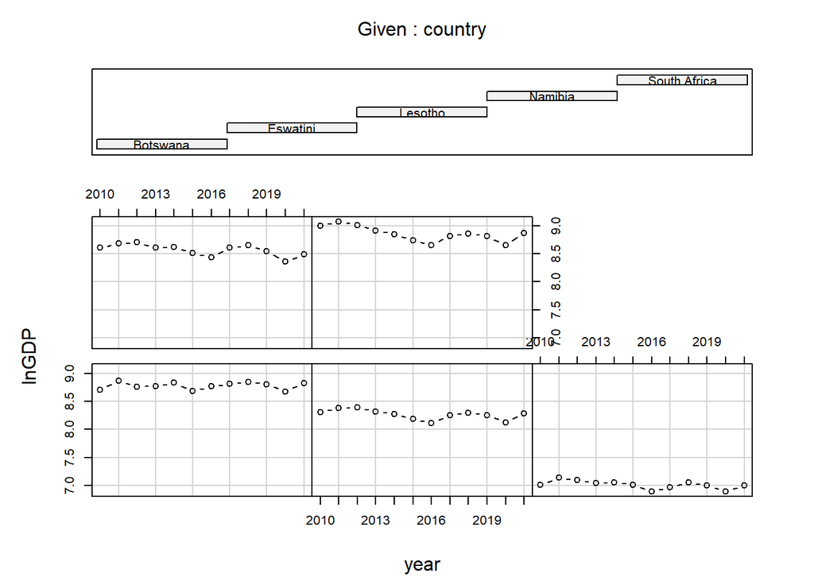

```r
# Exploring panel data
coplot(lnGDP ~ year|country, type="b", data=psacu)
```

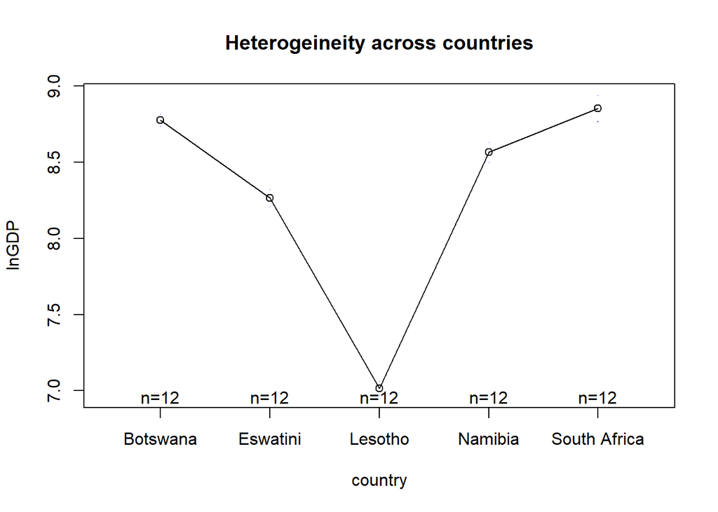

```r
plotmeans(lnGDP ~ country, main="Heterogeineity across countries", data=psacu)
```

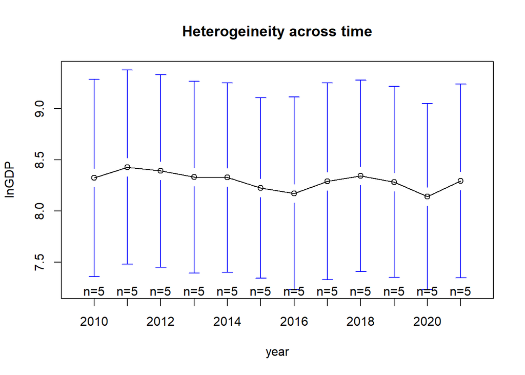

```r
plotmeans(lnGDP ~ year, main="Heterogeineity across time", data=psacu)
```

$\textbf{Descriptive statistics}$

```r
# Descriptive statistics

calculate_stats <- function(column) {
  mean_val <- mean(column)
  sd_val <- sd(column)
  median_val <- median(column)
  skewness_val <- skew(column)
  kurtosis_val <- kurtosi(column)

  return(c(mean = mean_val, sd = sd_val, median = median_val, skewness = skewness_val, kurtosis = kurtosis_val))
}
t(sapply(psacu[,3:10], calculate_stats)) %>% kbl() %>%
  kable_classic(full_width = F, html_font = "Roman")
```

|  | mean | sd | median | skewness | kurtosis |
| --- | --- | --- | --- | --- | --- |
| lnGDP | 8.2955448 | 0.6837362 | 8.6032746 | -1.1096130 | -0.3175648 |
| lnGOVEXP | 3.2904794 | 0.3415994 | 3.2417741 | 2.0703098 | 8.2706748 |
| lnTOP | 4.5004772 | 0.3119664 | 4.4827370 | -0.2309295 | -0.8555583 |
| lnFDI | 0.4509826 | 0.8629637 | 0.4758062 | 0.0896764 | -0.4522296 |
| lnINVEST | 21.5731878 | 2.9388952 | 21.6530471 | -3.6669725 | 21.5920443 |
| lnEXCHRATE | 2.4001770 | 0.2758601 | 2.3973328 | -0.3003152 | -1.3028278 |
| lnINFLA | 1.5611464 | 0.3250841 | 1.6023433 | -0.5532454 | 0.0492220 |
| LOCK | 0.0833333 | 0.2787178 | 0.0000000 | 2.9400506 | 6.7573485 |

$\textbf{Separate the data into with and without lockdown}$

```r
plock = psacu
psacu = psacu[,-10]
```

$\textbf{Estimation Model Of Panel Regression}$

$\textbf{1. Common Effect Model/ Pooled Regression}$

It is the simplest panel data model approach because it only combines time series data and cross sections. In this model, time and individual dimensions are not considered, so it is assumed that corporate data behavior is the same over various time periods. This method can use the Ordinary Least Square (OLS) approach or the least squares technique to estimate the panel data model.

```r
psacu.pool <- plm(lnGDP~lnGOVEXP+lnTOP+lnFDI+lnINVEST+lnEXCHRATE+lnINFLA, data = psacu, model = "pooling", index = c("country","year"))
summary(psacu.pool)
```

```
## Pooling Model
##
## Call:
## plm(formula = lnGDP ~ lnGOVEXP + lnTOP + lnFDI + lnINVEST + lnEXCHRATE +
##     lnINFLA, data = psacu, model = "pooling", index = c("country",
##     "year"))
##
## Balanced Panel: n = 5, T = 12, N = 60
##
## Residuals:
##       Min.    1st Qu.     Median    3rd Qu.       Max.
## -0.7690605 -0.3152241  0.0036325  0.3173410  0.8557908
##
## Coefficients:
##              Estimate Std. Error t-value  Pr(>|t|)
## (Intercept) 17.469185   1.923364  9.0826 2.178e-12 ***
## lnGOVEXP    -0.173615   0.303677 -0.5717 0.5699371
## lnTOP       -1.508932   0.292937 -5.1510 3.893e-06 ***
## lnFDI        0.032242   0.069379  0.4647 0.6440348
## lnINVEST     0.013415   0.029951  0.4479 0.6560418
## lnEXCHRATE  -0.782927   0.224601 -3.4859 0.0009937 ***
## lnINFLA     -0.151324   0.181855 -0.8321 0.4090785
## ---
## Signif. codes:  0 '***' 0.001 '**' 0.01 '*' 0.05 '.' 0.1 ' ' 1
##
## Total Sum of Squares:    27.582
## Residual Sum of Squares: 9.5409
## R-Squared:      0.65409
## Adj. R-Squared: 0.61493
## F-statistic: 16.7034 on 6 and 53 DF, p-value: 1.0557e-10
```

Individual effects of TOP,and EXCHRATE are also significant as p values are less than 5%. Here R2 is equal to 0.65409 which indicates a measure of fitness is good.

Adjusted R2: It is more reliable and accurate for evaluation. As R2 increases even if insignificant predictors are added but Adjusted R2 decreases as insignificant predictors are added. It is mainly used when you compare a model that has a different number of variables. Here Adjusted R2 is equal to 0.61493 which indicates the model is reliable.

Even if pooled OLS is having P-Value, less than 5% and R2 and Adjusted R2 indicates overall accuracy is excellent and the model is fit to use, we cannot rely on this model as it completely ignores heterogeneity.

```r
plock.pool <- plm(lnGDP~lnGOVEXP+lnTOP+lnFDI+lnINVEST+lnEXCHRATE+lnINFLA+LOCK, data = plock, model = "pooling", index = c("country","year"))
summary(plock.pool)
```

```
## Pooling Model
##
## Call:
## plm(formula = lnGDP ~ lnGOVEXP + lnTOP + lnFDI + lnINVEST + lnEXCHRATE +
##     lnINFLA + LOCK, data = plock, model = "pooling", index = c("country",
##     "year"))
##
## Balanced Panel: n = 5, T = 12, N = 60
##
## Residuals:
##       Min.    1st Qu.     Median    3rd Qu.       Max.
## -0.8012693 -0.2718639  0.0030865  0.2871940  0.8459098
##
## Coefficients:
##              Estimate Std. Error t-value  Pr(>|t|)
## (Intercept) 17.395640   1.933179  8.9985 3.490e-12 ***
## lnGOVEXP    -0.174838   0.304858 -0.5735  0.568773
## lnTOP       -1.500250   0.294289 -5.0979 4.886e-06 ***
## lnFDI        0.018478   0.071909  0.2570  0.798217
## lnINVEST     0.014448   0.030097  0.4801  0.633203
## lnEXCHRATE  -0.732464   0.234819 -3.1193  0.002955 **
## lnINFLA     -0.204825   0.195357 -1.0485  0.299274
## LOCK        -0.182037   0.236628 -0.7693  0.445197
## ---
## Signif. codes:  0 '***' 0.001 '**' 0.01 '*' 0.05 '.' 0.1 ' ' 1
##
## Total Sum of Squares:    27.582
## Residual Sum of Squares: 9.4335
## R-Squared:      0.65798
## Adj. R-Squared: 0.61194
## F-statistic: 14.2914 on 7 and 52 DF, p-value: 3.4511e-10
```

$\textbf{2. Fixed Effect Model}$

This model assumes that differences between individuals can be accommodated from their intercept differences. To estimate the Fixed Effects model panel data using variable dummy techniques to capture intercept differences between companies, intercept differences can occur due to differences in work culture, managerial, and incentives. However, the slopes are the same between companies. This estimation model is often called the Least Squares Dummy Variable (LSDV) technique.

```r
psacu.fe <- plm(lnGDP~lnGOVEXP+lnTOP+lnFDI+lnINVEST+lnEXCHRATE+lnINFLA, data = psacu, model = "within", index = c("country","year"), effect = "twoways")
summary(psacu.fe)
```

```
## Twoways effects Within Model
##
## Call:
## plm(formula = lnGDP ~ lnGOVEXP + lnTOP + lnFDI + lnINVEST + lnEXCHRATE +
##     lnINFLA, data = psacu, effect = "twoways", model = "within",
##     index = c("country", "year"))
##
## Balanced Panel: n = 5, T = 12, N = 60
##
## Residuals:
##       Min.    1st Qu.     Median    3rd Qu.       Max.
## -0.0642952 -0.0214399  0.0010346  0.0195424  0.0844819
##
## Coefficients:
##              Estimate Std. Error t-value  Pr(>|t|)
## lnGOVEXP   -0.1282179  0.0833946 -1.5375   0.13246
## lnTOP      -0.0498720  0.0694937 -0.7176   0.47736
## lnFDI       0.0163765  0.0089009  1.8399   0.07361 .
## lnINVEST   -0.0113101  0.0072073 -1.5693   0.12488
## lnEXCHRATE -0.8608407  0.1746865 -4.9279 1.662e-05 ***
## lnINFLA     0.0312742  0.0300705  1.0400   0.30490
## ---
## Signif. codes:  0 '***' 0.001 '**' 0.01 '*' 0.05 '.' 0.1 ' ' 1
##
## Total Sum of Squares:    0.11794
## Residual Sum of Squares: 0.059985
## R-Squared:      0.49137
## Adj. R-Squared: 0.21029
## F-statistic: 6.1185 on 6 and 38 DF, p-value: 0.00014839
```

```r
plock.fe <- plm(lnGDP~lnGOVEXP+lnTOP+lnFDI+lnINVEST+lnEXCHRATE+lnINFLA+LOCK, data = plock, model = "within", index = c("country","year"), effect = "twoways")
summary(plock.fe)
```

```
## Twoways effects Within Model
##
## Call:
## plm(formula = lnGDP ~ lnGOVEXP + lnTOP + lnFDI + lnINVEST + lnEXCHRATE +
##     lnINFLA + LOCK, data = plock, effect = "twoways", model = "within",
##     index = c("country", "year"))
##
## Balanced Panel: n = 5, T = 12, N = 60
##
## Residuals:
##       Min.    1st Qu.     Median    3rd Qu.       Max.
## -0.0642952 -0.0214399  0.0010346  0.0195424  0.0844819
##
## Coefficients:
##              Estimate Std. Error t-value  Pr(>|t|)
## lnGOVEXP   -0.1282179  0.0833946 -1.5375   0.13246
## lnTOP      -0.0498720  0.0694937 -0.7176   0.47736
## lnFDI       0.0163765  0.0089009  1.8399   0.07361 .
## lnINVEST   -0.0113101  0.0072073 -1.5693   0.12488
## lnEXCHRATE -0.8608407  0.1746865 -4.9279 1.662e-05 ***
## lnINFLA     0.0312742  0.0300705  1.0400   0.30490
## ---
## Signif. codes:  0 '***' 0.001 '**' 0.01 '*' 0.05 '.' 0.1 ' ' 1
##
## Total Sum of Squares:    0.11794
## Residual Sum of Squares: 0.059985
## R-Squared:      0.49137
## Adj. R-Squared: 0.21029
## F-statistic: 6.1185 on 6 and 38 DF, p-value: 0.00014839
```

$\textbf{3. Random Effect Model}$

This model will estimate panel data where interruption variables may be interconnected between time and between individuals. In the Random Effect model, intercept differences are accommodated by the error terms of each company. The advantage of using the Random Effect model is to eliminate heteroscedasticity. This model is also called the Error Component Model (ECM) or the Generalized Least Square (GLS) technique

```r
psacu.re <- plm(lnGDP~lnGOVEXP+lnTOP+lnFDI+lnINVEST+lnEXCHRATE+lnINFLA, data = psacu, model = "random", index = c("country","year"), effect = "twoways",random.method = "walhus")
summary(psacu.re)
```

```
## Twoways effects Random Effect Model
##    (Wallace-Hussain's transformation)
##
## Call:
## plm(formula = lnGDP ~ lnGOVEXP + lnTOP + lnFDI + lnINVEST + lnEXCHRATE +
##     lnINFLA, data = psacu, effect = "twoways", model = "random",
##     random.method = "walhus", index = c("country", "year"))
##
## Balanced Panel: n = 5, T = 12, N = 60
##
## Effects:
##                    var  std.dev share
## idiosyncratic 0.027004 0.164328 0.170
## individual    0.123147 0.350923 0.777
## time          0.008415 0.091732 0.053
## theta: 0.866 (id) 0.3748 (time) 0.3729 (total)
##
## Residuals:
##      Min.   1st Qu.    Median   3rd Qu.      Max.
## -0.192090 -0.058423  0.031121  0.060349  0.161661
##
## Coefficients:
##              Estimate Std. Error z-value  Pr(>|z|)
## (Intercept) 11.939881   1.041889 11.4598 < 2.2e-16 ***
## lnGOVEXP    -0.204326   0.185303 -1.1027 0.2701753
## lnTOP       -0.432404   0.147970 -2.9222 0.0034753 **
## lnFDI        0.015723   0.019702  0.7980 0.4248613
## lnINVEST    -0.013797   0.015885 -0.8685 0.3850949
## lnEXCHRATE  -0.313210   0.080634 -3.8843 0.0001026 ***
## lnINFLA      0.010459   0.050280  0.2080 0.8352119
## ---
## Signif. codes:  0 '***' 0.001 '**' 0.01 '*' 0.05 '.' 0.1 ' ' 1
##
## Total Sum of Squares:    0.75257
## Residual Sum of Squares: 0.50428
## R-Squared:      0.32992
## Adj. R-Squared: 0.25406
## Chisq: 26.0948 on 6 DF, p-value: 0.00021377
```

```r
plock.re <- plm(lnGDP~lnGOVEXP+lnTOP+lnFDI+lnINVEST+lnEXCHRATE+lnINFLA+LOCK, data = plock, model = "random", index = c("country","year"), effect = "twoways",random.method = "walhus")
summary(plock.re)
```

```
## Twoways effects Random Effect Model
##    (Wallace-Hussain's transformation)
##
## Call:
## plm(formula = lnGDP ~ lnGOVEXP + lnTOP + lnFDI + lnINVEST + lnEXCHRATE +
##     lnINFLA + LOCK, data = plock, effect = "twoways", model = "random",
##     random.method = "walhus", index = c("country", "year"))
##
## Balanced Panel: n = 5, T = 12, N = 60
##
## Effects:
##                    var  std.dev share
## idiosyncratic 0.028584 0.169069 0.182
## individual    0.123161 0.350943 0.786
## time          0.005004 0.070736 0.032
## theta: 0.8623 (id) 0.2698 (time) 0.2686 (total)
##
## Residuals:
##      Min.   1st Qu.    Median   3rd Qu.      Max.
## -0.205210 -0.068430  0.029505  0.062079  0.163130
##
## Coefficients:
##               Estimate Std. Error z-value  Pr(>|z|)
## (Intercept) 12.0063766  1.0470013 11.4674 < 2.2e-16 ***
## lnGOVEXP    -0.1983655  0.1883285 -1.0533 0.2922059
## lnTOP       -0.4708775  0.1497951 -3.1435 0.0016695 **
## lnFDI        0.0114833  0.0202932  0.5659 0.5714826
## lnINVEST    -0.0127560  0.0161284 -0.7909 0.4290007
## lnEXCHRATE  -0.2704230  0.0761267 -3.5523 0.0003819 ***
## lnINFLA     -0.0063085  0.0517724 -0.1219 0.9030171
## LOCK        -0.1202534  0.0745051 -1.6140 0.1065209
## ---
## Signif. codes:  0 '***' 0.001 '**' 0.01 '*' 0.05 '.' 0.1 ' ' 1
##
## Total Sum of Squares:    0.83453
## Residual Sum of Squares: 0.51587
## R-Squared:      0.38184
## Adj. R-Squared: 0.29863
## Chisq: 32.1211 on 7 DF, p-value: 3.8569e-05
```

$$\textbf{Selection of Panel Data Testing
Method}$$
$\textbf{Chow Test For Poolability}$

Chow test is a test to determine the model of whether Pooled Effect or Fixed Effect (FE) is most appropriately used in estimating panel data. What is poolability? Poolability asks if slopes are the same across group or overtime. If the results state that they accept the null hypothesis, then the best model to use is the Common Effect Model. However, if the results state that they reject the null hypothesis then the best model used is the Fixed Effect Model, and the test will continue to the Hausman test. Chow test is a test to determine the Common Effect or Fixed Effect model that is most appropriate to be used in estimating panel data. The hypothesis in the chow test is:

H0: Common Effect Model or pooled OLS

H1: Fixed Effect Model

```r
pFtest(psacu.fe,psacu.pool)
```

```
##
##  F test for twoways effects
##
## data:  lnGDP ~ lnGOVEXP + lnTOP + lnFDI + lnINVEST + lnEXCHRATE + lnINFLA
## F = 400.41, df1 = 15, df2 = 38, p-value < 2.2e-16
## alternative hypothesis: significant effects
```

```r
pFtest(plock.fe,plock.pool)
```

```
##
##  F test for twoways effects
##
## data:  lnGDP ~ lnGOVEXP + lnTOP + lnFDI + lnINVEST + lnEXCHRATE + lnINFLA +  ...
## F = 424.15, df1 = 14, df2 = 38, p-value < 2.2e-16
## alternative hypothesis: significant effects
```

From the result above, we can see the p-value is below 0.05 so a fixed effect model is better for both data

$\textbf{Hausman Test}$

Hausman test is a test to determine the Fixed Effet or Random Effect model that is best used in estimating panel data. The hypothesis in the chow test is:

H0: Random Effect Model

H1: Fixed Effect Model

If the Hausman Test results state that it accepts the null hypothesis, the best model to use is the Random Effect model. However, if the results state that they reject the null hypothesis, the best model used is the Fixed Effect model.

```r
phtest(psacu.fe, psacu.re)
```

```
##
##  Hausman Test
##
## data:  lnGDP ~ lnGOVEXP + lnTOP + lnFDI + lnINVEST + lnEXCHRATE + lnINFLA
## chisq = 3.8046, df = 6, p-value = 0.7031
## alternative hypothesis: one model is inconsistent
```

```r
phtest(plock.fe, plock.re)
```

```
##
##  Hausman Test
##
## data:  lnGDP ~ lnGOVEXP + lnTOP + lnFDI + lnINVEST + lnEXCHRATE + lnINFLA +  ...
## chisq = 4.5948, df = 6, p-value = 0.5967
## alternative hypothesis: one model is inconsistent
```

The random effect model is an appropriate estimator, meaning fixed effects are probably correlated with $Y_{it}$.

$\textbf{Lagrange Multiplier Test}$

Lagrange Multiplier Test Test or commonly referred to as Lagrangian Multiplier Test is an analysis performed with the aim to determine the best method in panel data regression, whether to use common effect or random effect. The Lagrange Multiplier test has a function to determine the best estimate, whether using a random effect or not.

when doing data panel regression, namely :

1. The Chow Test shows that the best method is the Common Effect of the fixed effect. So the next step to determine whether the Common Effect is better than the Random Effect, then the Lagrange Multiplier Test is required.
2. The Hausman Test test shows that the best method is the Random effect of the Fixed Effect. So the next step to determine whether the Random Effect is better than the Common Effect, then the Lagrange Multiplier Test is required.

```r
plmtest(psacu.fe,effect = "twoways",type = "bp")
```

```
##
##  Lagrange Multiplier Test - two-ways effects (Breusch-Pagan)
##
## data:  lnGDP ~ lnGOVEXP + lnTOP + lnFDI + lnINVEST + lnEXCHRATE + lnINFLA
## chisq = 197.73, df = 2, p-value < 2.2e-16
## alternative hypothesis: significant effects
```

```r
plmtest(plock.fe,effect = "twoways",type = "bp")
```

```
##
##  Lagrange Multiplier Test - two-ways effects (Breusch-Pagan)
##
## data:  lnGDP ~ lnGOVEXP + lnTOP + lnFDI + lnINVEST + lnEXCHRATE + lnINFLA +  ...
## chisq = 204.12, df = 2, p-value < 2.2e-16
## alternative hypothesis: significant effects
```

From the results above, the p-value is below 0.05 for both models, so a random effect model is better for this data

$\textbf{Diagnostic tests}$

$\textbf{1. Test Of Serial Correlation}$

Serial correlation is the relationship between a variable and a lagged version of itself over various time intervals.

Serial correlation hypothesis test:

H0: There is not serial correlation

H1: There is serial correlation

```r
# Test Of Serial Correlation

pbgtest(psacu.re)
```

```
##
##  Breusch-Godfrey/Wooldridge test for serial correlation in panel models
##
## data:  lnGDP ~ lnGOVEXP + lnTOP + lnFDI + lnINVEST + lnEXCHRATE + lnINFLA
## chisq = 31.542, df = 12, p-value = 0.001628
## alternative hypothesis: serial correlation in idiosyncratic errors
```

```r
pbgtest(plock.re)
```

```
##
##  Breusch-Godfrey/Wooldridge test for serial correlation in panel models
##
## data:  lnGDP ~ lnGOVEXP + lnTOP + lnFDI + lnINVEST + lnEXCHRATE + lnINFLA +  ...
## chisq = 33, df = 12, p-value = 0.0009681
## alternative hypothesis: serial correlation in idiosyncratic errors
```

The result show that the p-value is less than 0.05 so there is serial correlation. Serial correlation tests apply to macro panels with long time series. Not a problem in micro panels (with very few years). Thus we can continue to use the data to construct our models.

$\text{2. Heteroscedasticity}$

Heteroskedasticity occurs for a linear relationship when the variance is not a constant and it increases as the predictor increases. In such cases, the standard error in the output cannot be relied on but still, coefficients will be unbiased. The best way to detect heteroskedasticity is by Graphical method or Breusch-Pagan (BP) test

Breusch-Pagan (BP) fits a linear regression model to the residuals of a linear regression model (by default the same explanatory variables are taken as in the main regression model) and rejects if too much of the variance is explained by the additional explanatory variables.

For the BP test we assume there is no heteroscedasticity(is homoskedasticity) as a null hypothesis and the existence of heteroscedasticity as the alternative hypothesis.

Under H0 the test statistic of the Breusch-Pagan test follows a chi-squared distribution with parameter (the number of regressors without the constant in the model) degrees of freedom.

```r
# Breusch-Pagan test
bptest(psacu.re, data = psacu, studentize=F)
```

```
##
##  Breusch-Pagan test
##
## data:  psacu.re
## BP = 20.503, df = 6, p-value = 0.002253
```

```r
bptest(plock.re, data = plock, studentize=F)
```

```
##
##  Breusch-Pagan test
##
## data:  plock.re
## BP = 21.904, df = 7, p-value = 0.002639
```

As the P-value of the BP test is less than 5%, indicates the variance is changing in the residual as the predictor value increases, thus we reject the null hypothesis. Therefore, there is heteroscedasticity in the data